# Gráficos com ggplot2

```r
# bibliotecas utilizadas
if (!"Hmisc" %in% installed.packages()) install.packages("Hmisc")
if (!"ggcorrplot" %in% installed.packages()) install.packages("ggcorrplot")
library(tidyverse)
library(lubridate)
library(magrittr)
library(Hmisc)
```

## Por que visualizar os dados?

- [Quarteto de Anscombe e a importância da visualização](https://pt.wikipedia.org/wiki/Quarteto_de_Anscombe)
- [Datasaurus Dozen](https://www.autodeskresearch.com/publications/samestats)

## O que é análise exploratória com gráficos?

[Wikipedia](https://pt.wikipedia.org/wiki/An%C3%A1lise_explorat%C3%B3ria_de_dados)

- Forma de responder visualmente a questões levantadas sobre propriedades e relacionamentos entre variáveis de um *dataset*.
- Complemento visual para as estatísticas descritivas.
- Fase de descoberta de problemas, padrões e relacionamentos.
- Fundamental para modelagem e para a comunicação.

## ggplot2 (1)

Biblioteca gráfica baseada na [gramática dos gráficos composta em camadas](http://vita.had.co.nz/papers/layered-grammar.html).

- Conecta variáveis de Data Frames com elementos gráficos através de abstrações que tornam a visualização independente dos dados tabulares.
- Resolve de forma simples muitas das complexidades da criação de gráficos, como posicionamento de legendas, escalas de cores e formatação de textos em gráficos.
- Expõe um modelo de composição em camadas que facilita o enriquecimento visual através da adição de camadas.

## ggplot2 (2)

Cumpre um papel dual:

- Fornece resultados gráficos de alta qualidade, utilizado em publicações e sites de notícias
  - FiveThirtyEight, New York Times são exemplos
- Possibilita a criação de visualizações rápidas para análise exploratória com poucas linhas

O modelo de adição de camadas permite enriquecer um gráfico exploratório simples para ter qualidade de publicação.

| title | views | comments | duration | event | film_date | languages | main_speaker | num_speaker | published_date | speaker_occupation |
| --- | --- | --- | --- | --- | --- | --- | --- | --- | --- | --- |
| Do schools kill creativity? | 47227110 | 4553 | 1164s (~19.4 minutes) | TED2006 | 2006-02-25 | 60 | Ken Robinson | 1 | 2006-06-27 00:11:00 | Author/educator |
| Averting the climate crisis | 3200520 | 265 | 977s (~16.28 minutes) | TED2006 | 2006-02-25 | 43 | Al Gore | 1 | 2006-06-27 00:11:00 | Climate advocate |
| Simplicity sells | 1636292 | 124 | 1286s (~21.43 minutes) | TED2006 | 2006-02-24 | 26 | David Pogue | 1 | 2006-06-27 00:11:00 | Technology columnist |
| Greening the ghetto | 1697550 | 200 | 1116s (~18.6 minutes) | TED2006 | 2006-02-26 | 35 | Majora Carter | 1 | 2006-06-27 00:11:00 | Activist for environmental justice |
| The best stats you've ever seen | 12005869 | 593 | 1190s (~19.83 minutes) | TED2006 | 2006-02-22 | 48 | Hans Rosling | 1 | 2006-06-27 20:38:00 | Global health expert; data visionary |
| Why we do what we do | 20685401 | 672 | 1305s (~21.75 minutes) | TED2006 | 2006-02-02 | 36 | Tony Robbins | 1 | 2006-06-27 20:38:00 | Life coach; expert in leadership psychology |
| Letting go of God | 3769987 | 919 | 992s (~16.53 minutes) | TED2006 | 2006-02-24 | 31 | Julia Sweeney | 1 | 2006-07-10 00:11:00 | Actor, comedian, playwright |
| Behind the design of Seattle's library | 967741 | 46 | 1198s (~19.97 minutes) | TED2006 | 2006-02-23 | 19 | Joshua Prince-Ramus | 1 | 2006-07-10 00:11:00 | Architect |
| Let's teach religion -- all religion -- in schools | 2567958 | 852 | 1485s (~24.75 minutes) | TED2006 | 2006-02-02 | 32 | Dan Dennett | 1 | 2006-07-18 00:11:00 | Philosopher, cognitive scientist |
| A life of purpose | 3095993 | 900 | 1262s (~21.03 minutes) | TED2006 | 2006-02-25 | 31 | Rick Warren | 1 | 2006-07-18 00:11:00 | Pastor, author |

[output cut: 990 more lines]

## Componentes mínimos necessários

O `ggplot`, assim como o `dplyr`, utiliza uma DSL (Domain Specific Language, Linguagem Específica de Domínio) que descreve seus componente.

Os principais conceitos do `ggplot` são:

- **canvas**, espaço visual onde formas geométricas serão exibidas
- **estéticas**, que são propriedades visuais dos elementos gráficos
- **mapeamento de estéticas**, que conecta as propriedades visuais com variáveis dos data frames
- **geometrias**, formas geométricas exibidas no canvas
- **escalas**, que são controles visuais das variáveis mapeadas para estéticas
- **tema**, que define atributos visuais do canvas

Tomando como exemplo um gráfico de pontos, vamos visualizar a quantidade de linguagens por vídeo ao longo dos anos. Para este gráfico escolhi utilizar a data de filmagem.

- Iniciamos com a criação da variável ano a partir da variável film_date. O data frame resultante desta transformação é conectado às propriedades visuais por meio do mapeamento de estéticas, que conecta a variável year com o eixo **x** e a variável languages com o eixo **y**. Estas variáveis serão utilizadas como *default* em todas as formas geométricas deste gráfico.
- A seguir, utilizamos a forma geométrica do ponto. Neste exemplo modificamos a propriedade *alpha* para adicionar transparência ao preencimento do ponto. Esta transparência facilita a identificação visual da concentração de pontos em um mesmo par (x, y)
- A escala *x* é modificada para que os rótulos exibam os anos de 5 em 5.
- Escolho o tema theme_bw, que utiliza padrões de preto e branco.

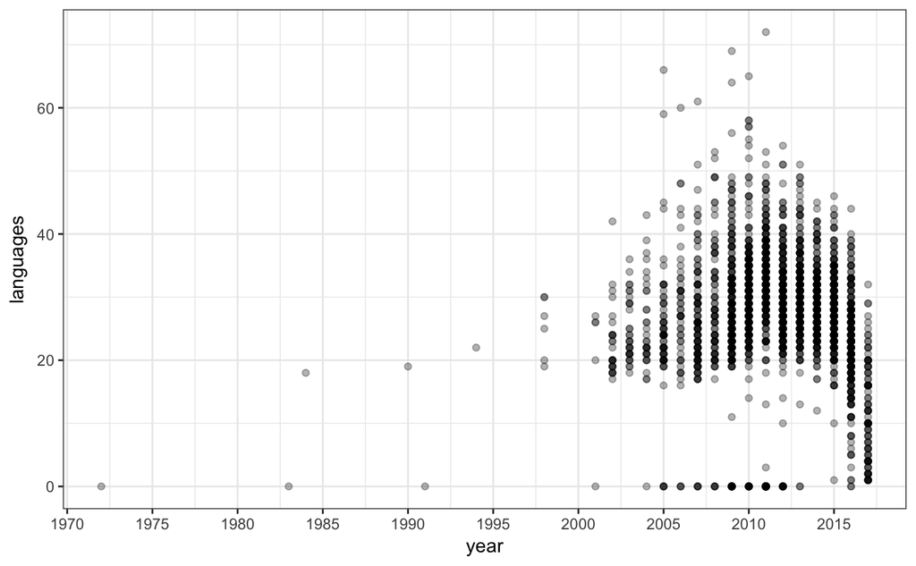

```r
ted_talks %>%
  mutate( year = year( film_date )) %>%
ggplot( aes( x = year, y = languages )) +
  geom_point( alpha = .3 ) +
  scale_x_continuous( breaks = seq( from = 1970, to = 2020, by = 5 )) +
  theme_bw()
```

### Análise do gráfico

O que identificamos em relação aos mínimos e máximos? Onde temos maior ocorrência de apresentações, nos eixos x e y? Que padrões a transparência destaca?

## Rótulos

No ggplot2 os rótulos podem ser inseridos de diferentes formas. A forma mais consistente é através da função **labs**, que possibilita informar o rótulo de cada estética. No exemplo abaixo atualizei os rótulos dos eixos **x** e **y**, e aproveitei para inserir títulos no gráfico.

Seguindo com o exemplo de Quantidade de Línguas por ano, vamos reduzir o período para considerar somente apresentações de 2005 em diante. Vídeos que estavam sem quantidade de línguas foram modificados para ter 1 língua.

Pelo padrão abaixo, a decisão de inserir artificialmente 1 língua pareceu acertada?

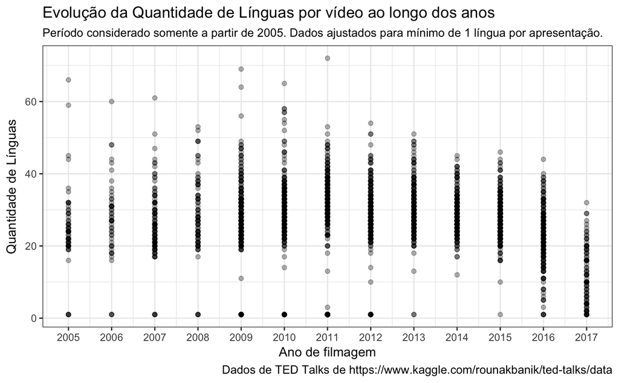

```r
ted_talks_recentes <- ted_talks %>%
  filter(film_date >= ymd(20050101)) %>%
  mutate(languages = if_else(languages == 0, 1L, languages))
ted_talks_recentes %>%
  mutate( year = year( film_date )) %>%
ggplot( aes( x = year, y = languages )) +
  geom_point( alpha = .3 ) +
  scale_x_continuous( breaks = 2005:2017) +
  labs( x = "Ano de filmagem"
      , y = "Quantidade de Línguas"
      , title = "Evolução da Quantidade de Línguas por vídeo ao longo dos anos"
      , subtitle = "Período considerado somente a partir de 2005. Dados ajustados para mínimo de 1 língua por apresentação."
      , caption = "Dados de TED Talks de https://www.kaggle.com/rounakbanik/ted-talks/data") +
  theme_bw()
```

## Estatísticas

Estatísticas são combinações de formas geométricas que apresentam visualmente o resultado de estatísticas aplicadas sobre grupos. No exemplo abaixo substituimos a forma de pontos pela forma de resumo `stat_summary`. Esta forma requer uma função que será aplicada sobre a estética **y** para dela derivar um novo **y** central, e mais as estéticas **ymin** e **ymax**. A função escolhida neste caso foi a função `mean_sdl` que retorna o **y** central como a média, o **ymin** como 2 desvios padrão abaixo da média e **ymax** como 2 desvios padrão acima da média.

- Incluí uma escala para o eixo y
- Reparem que é possível acrescentar quebras nos textos. Neste caso inseri uma quebra de linha no subtítulo

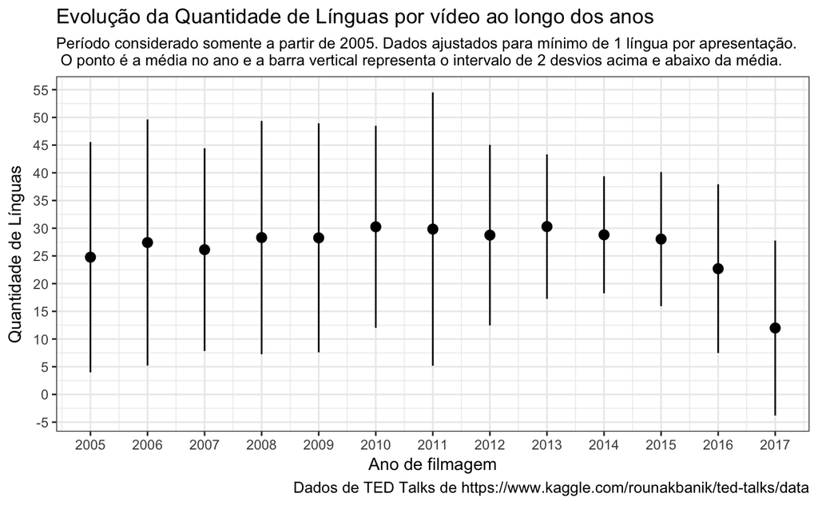

```r
ted_talks_recentes %>%
  mutate( year = year( film_date )) %>%
ggplot( aes( x = year, y = languages )) +
  stat_summary(fun.data = mean_sdl) +
  scale_x_continuous( breaks = 2005:2017 ) +
  scale_y_continuous( breaks = seq(from = -10, to = 60, by = 5 )) +
  labs( x = "Ano de filmagem"
      , y = "Quantidade de Línguas"
      , title = "Evolução da Quantidade de Línguas por vídeo ao longo dos anos"
      , subtitle = "Período considerado somente a partir de 2005. Dados ajustados para mínimo de 1 língua por apresentação.\n O ponto é a média no ano e a barra vertical representa o intervalo de 2 desvios acima e abaixo da média."
      , caption = "Dados de TED Talks de https://www.kaggle.com/rounakbanik/ted-talks/data") +
  theme_bw()
```

> ATIVIDADE

Repetir os gráficos de pontos e de sumário utilizando o ano de publicação no eixo x e a duração no eixo y. Cuidado com a escala do eixo y!

> FIM ATIVIDADE

## Gráficos de barras

Diferentes formas geométricas do `ggplot` resultam em barras:

- `geom_col`, quando uma variável do data frame representa o tamanho da barra. Requer as estéticas **x** e **y**.
- `geom_bar`, quando o tamanho da barra for a contagem de observações. Requer a estética **x**.

#### Exemplo com geom_col

Neste exemplo vemos que é possível determinar a cor de preenchimento da barra através da estética **fill**. Vemos também que é possível formatar um eixo em milhares utilizando a função `format_format` do pacote `scales`.

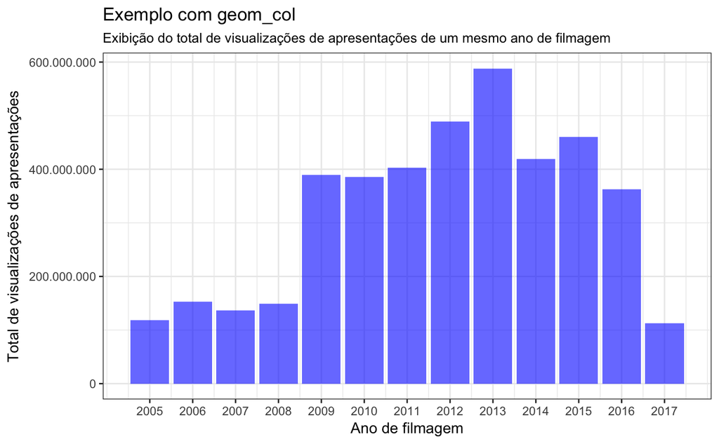

```r
ted_talks_recentes %>%
  mutate( year = year( film_date )) %>%
  group_by(year) %>%
  summarise(sum_views = sum(views)) %>%
  ungroup() %>%
ggplot( aes( x = year, y = sum_views )) +
  geom_col(fill="blue", alpha=0.6) +
  scale_x_continuous(breaks = 2005:2017) +
  scale_y_continuous(labels = scales::format_format(big.mark = ".", decimal.mark=",", scientific = FALSE)) +
  labs( x = "Ano de filmagem"
      , y = "Total de visualizações de apresentações"
      , title = "Exemplo com geom_col"
      , subtitle = "Exibição do total de visualizações de apresentações de um mesmo ano de filmagem") +
  theme_bw()
```

#### Exemplo com geom_bar

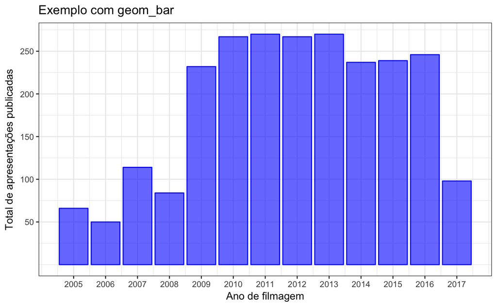

```r
ggplot(ted_talks_recentes,  aes( x = year( film_date ))) +
  geom_bar( fill="blue", color = "blue", alpha=0.6 ) +
  scale_x_continuous( breaks = 2005:2017 ) +
  scale_y_continuous( breaks = seq( from = 50, to = 300, by = 50 )) +
  labs( x = "Ano de filmagem"
      , y = "Total de apresentações publicadas"
      , title = "Exemplo com geom_bar" ) +
  theme_bw()
```

#### Cores e grupos

No ggplot podemos determinar a cor de uma forma geométrica a partir do mapeamento de uma estética. As cores podem ser em escala contínua quando a variável for numérica e em paletas de cores quando a variável for categórica.

No exemplo abaixo, distiguimos a quantidade de apresentações publicadas por mês utilizando diferentes cores.

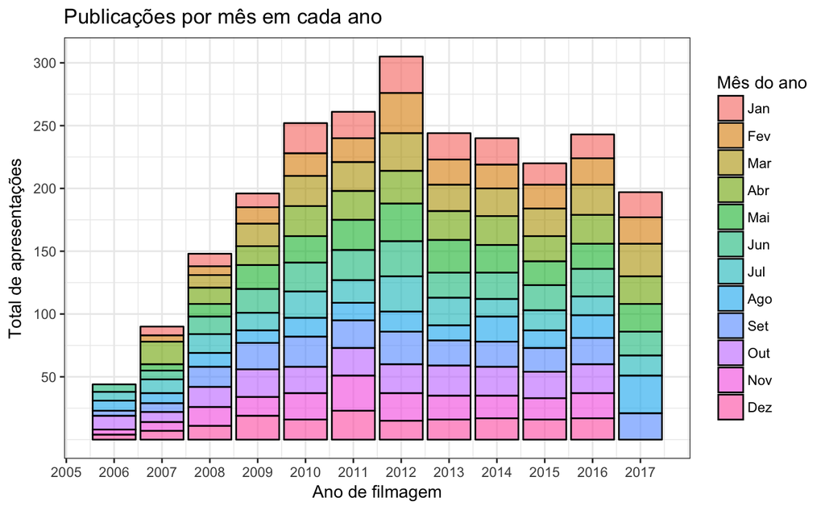

```r
ted_talks_recentes %>%
  mutate( ano = year( published_date ), mes = month( published_date, label = TRUE )) %>%
ggplot(aes( x = ano, fill = mes )) +
  geom_bar( alpha=0.6, color="black" ) +
  scale_x_continuous( breaks = 2005:2017 ) +
  scale_y_continuous( breaks = seq( from = 50, to = 300, by = 50 )) +
  labs( x = "Ano de filmagem"
      , y = "Total de apresentações"
      , fill = "Mês do ano"
      , title = "Publicações por mês em cada ano" ) +
  theme_bw()
```

## Facetas

Facetas são um recurso que possibilita a divisão de um canvas em vários gráficos homogêneos, separados por uma variável do data frame.

Neste exemplo repetimos o gráfico de barras original utilizando a função **facet_wrap**. Por meio desta função temos agora um gráfico por mês, organizados em um grid 3 x 4.

Ainda, o tema foi modificado para que o texto do eixo **x** seja exibido em um ângulo de 45 graus, viabilizando a exibição de todos os anos do intervalo.

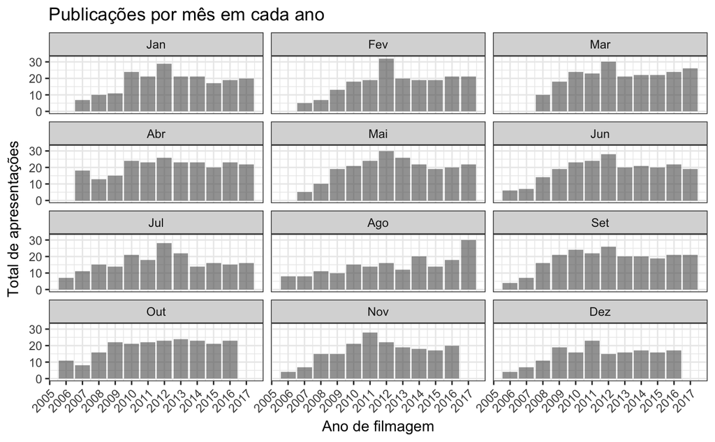

```r
ted_talks_recentes %>%
  mutate( ano = year( published_date ), mes = month( published_date, label = TRUE )) %>%
ggplot(aes( x = ano )) +
  geom_bar( alpha=0.6 ) +
  scale_x_continuous( breaks = 2005:2017 ) +
  facet_wrap (~ mes, ncol = 3 ) +
  labs( x = "Ano de filmagem"
      , y = "Total de apresentações"
      , fill = "Mês do ano"
      , title = "Publicações por mês em cada ano" ) +
  theme_bw() +
  theme(axis.text.x = element_text(angle = 45, hjust = 1))
```

## Boxplot

Boxplot é um tipo de gráfico que apresenta as relações de quartis de forma estruturada e contextualizada, além de indicar as faixas de valores.

Como o ano é uma variável numérica, é necessário um mapeamento de estética para que a forma geométrica de boxplot compreenda como um grupo.

O boxplot apresenta as seguintes estatísticas:

- **Mediana**, a linha horizontal localizada dentro do retângulo.
- **Primeiro e terceiro quartis**, limites inferior e superior do retângulo.
- Relação Interquartil (**IQR**), onde:
  - a linha vertical superior alcança o maior valor menor ou igual a 1.5 * o IQR somado ao terceiro quartil
  - a linha vertical inferior alcança o menor valor maior ou igual a 1.5 * o IQR subtraído do primeiro quartil
- **Outliers**, que são quaisquer medidas que excedem as linhas de IQR

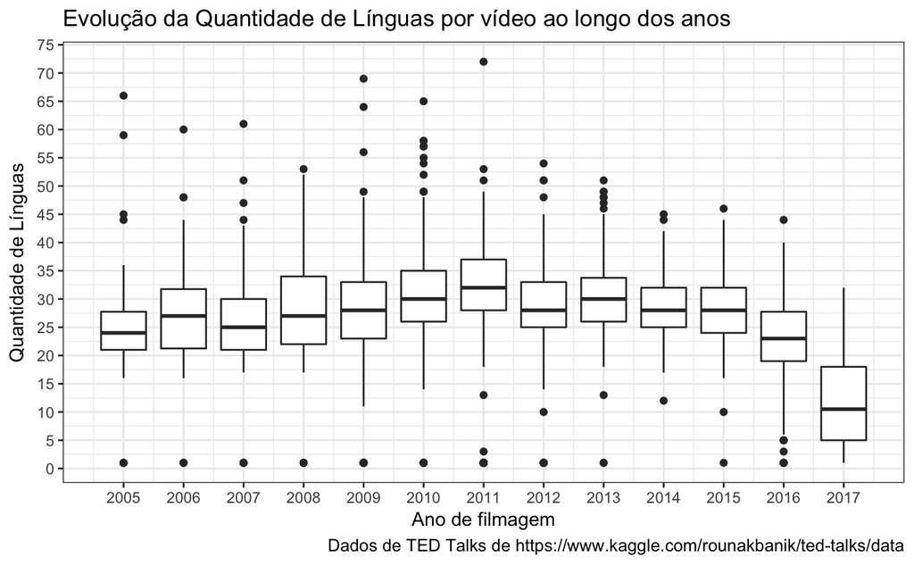

```r
ted_talks_recentes %>%
  mutate( year = year( film_date )) %>%
ggplot( aes( x = year, y = languages, group = year )) +
  geom_boxplot() +
  scale_x_continuous( breaks = 2005:2017 ) +
  scale_y_continuous( breaks = seq(from = 0, to = 100, by = 5 )) +
  labs( x = "Ano de filmagem"
      , y = "Quantidade de Línguas"
      , title = "Evolução da Quantidade de Línguas por vídeo ao longo dos anos"
      , caption = "Dados de TED Talks de https://www.kaggle.com/rounakbanik/ted-talks/data") +
  theme_bw()
```

A forma geométrica de boxplot do ggplot2 possibilita customizar alguns dos componentes. No exemplo abaixo modifiquei a cor e a transparência dos pontos de outlier.

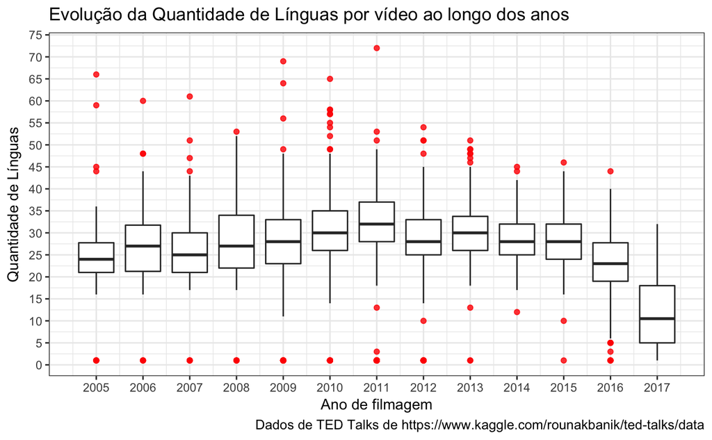

```r
ted_talks_recentes %>%
  mutate( year = year( film_date )) %>%
ggplot( aes( x = year, y = languages, group = year )) +
  geom_boxplot(outlier.color = "red", outlier.alpha = 0.8) +
  scale_x_continuous( breaks = 2005:2017 ) +
  scale_y_continuous( breaks = seq(from = 0, to = 100, by = 5 )) +
  labs( x = "Ano de filmagem"
      , y = "Quantidade de Línguas"
      , title = "Evolução da Quantidade de Línguas por vídeo ao longo dos anos"
      , caption = "Dados de TED Talks de https://www.kaggle.com/rounakbanik/ted-talks/data") +
  theme_bw()
```

### Composição com múltiplos gráficos

Assim como compomos gráficos combinando escalas, mapeamentos de estéticas e formas geométricas, podemos também combinar múltiplasa formas geométricas. O exemplo abaixo combina o boxplot com gráfico de pontos para ilustrar como as observações estão distribuídas.

- **Jitter** (tremor) é uma variação de gráfico de pontos onde a posição é deslocada aleatoriamente em uma fração de altura e de largura. O exemplo abaixo aplica **jitter** para distribuir horizontalmente de forma que todas as observações estejam visíveis dentro de cada ano. Foi necessário aplicar uma transparência para melhor identificar a concentração
- As formas geométricas são sobrepostas na ordem em que são adicionadas ao canvas. No exemplo abaixo apliquei transparência no boxplot para que seja possível visualizar os pontos.

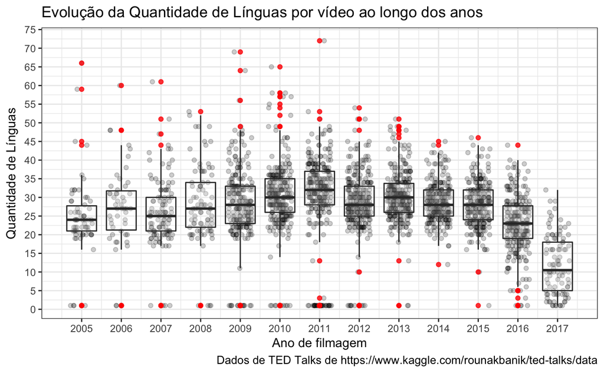

```r
ted_talks_recentes %>%
  mutate( year = year( film_date )) %>%
ggplot( aes( x = year, y = languages, group = year )) +
  geom_jitter(alpha = .2, height = 0, width = 0.3) +
  geom_boxplot(outlier.color = "red", outlier.alpha = 0.8, alpha = 0.2) +
  scale_x_continuous( breaks = 2005:2017 ) +
  scale_y_continuous( breaks = seq(from = 0, to = 100, by = 5 )) +
  labs( x = "Ano de filmagem"
      , y = "Quantidade de Línguas"
      , title = "Evolução da Quantidade de Línguas por vídeo ao longo dos anos"
      , caption = "Dados de TED Talks de https://www.kaggle.com/rounakbanik/ted-talks/data") +
  theme_bw()
```

Combinando **jitter** com **stat_summary**

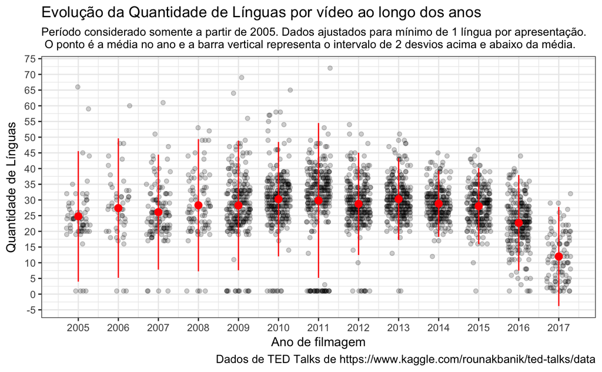

```r
ted_talks_recentes %>%
  mutate( year = year( film_date )) %>%
ggplot( aes( x = year, y = languages )) +
  geom_jitter(alpha = .2, height = 0, width = 0.3) +
  stat_summary(fun.data = mean_sdl, color="red") +
  scale_x_continuous( breaks = 2005:2017 ) +
  scale_y_continuous( breaks = seq(from = -10, to = 80, by = 5 )) +
  labs( x = "Ano de filmagem"
      , y = "Quantidade de Línguas"
      , title = "Evolução da Quantidade de Línguas por vídeo ao longo dos anos"
      , subtitle = "Período considerado somente a partir de 2005. Dados ajustados para mínimo de 1 língua por apresentação.\n O ponto é a média no ano e a barra vertical representa o intervalo de 2 desvios acima e abaixo da média."
      , caption = "Dados de TED Talks de https://www.kaggle.com/rounakbanik/ted-talks/data") +
  theme_bw()
```

## Faixas de banda

A forma geométrica de banda é outra maneira de demarcar visualmente os limites superior e inferior através de estatísticas descritivas. Esta forma requer as estéticas **ymin** e **ymax**, que foram previamente calculadas no Data Frame.

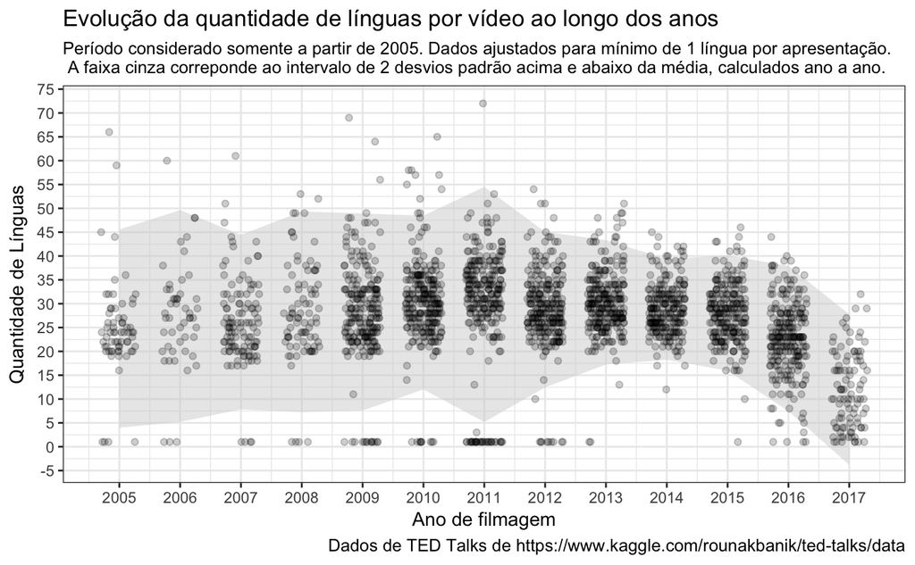

```r
ted_talks_recentes %>%
  mutate( year = year( film_date )) %>%
  group_by(year) %>%
  mutate(low = mean(languages) - 2 * sd(languages), hi = mean(languages) + 2 * sd(languages)) %>%
  ungroup() %>%
ggplot( aes( x = year, y = languages, ymin = low, ymax = hi )) +
  geom_ribbon(fill = "lightgray", alpha = 0.5) +
  geom_jitter(alpha = .2, height = 0, width = 0.3) +
  scale_x_continuous( breaks = 2005:2017 ) +
  scale_y_continuous( breaks = seq(from = -10, to = 80, by = 5 )) +
  labs( x = "Ano de filmagem"
      , y = "Quantidade de Línguas"
      , title = "Evolução da quantidade de línguas por vídeo ao longo dos anos"
      , subtitle = "Período considerado somente a partir de 2005. Dados ajustados para mínimo de 1 língua por apresentação.\n A faixa cinza correponde ao intervalo de 2 desvios padrão acima e abaixo da média, calculados ano a ano."
      , caption = "Dados de TED Talks de https://www.kaggle.com/rounakbanik/ted-talks/data") +
  theme_bw()
```

## Correlograma

**ggcorrplot** possibilita visualizar as correlações entre variáveis numéricas. A matriz de correlações deve ser previamente calculada utilizando a função `cor`.

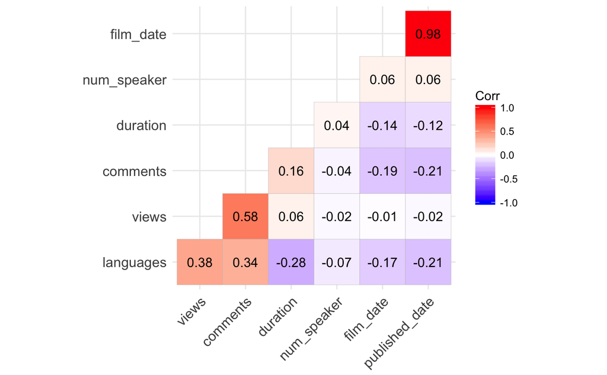

```r
library(ggcorrplot)
corr <-
  ted_talks_recentes %>%
  select_if(is_numeric) %>%
  mutate( duration = as.numeric(duration)
        , published_date = as.numeric(published_date)
        , film_date = as.numeric(film_date)) %>%
  select(-event, -speaker_occupation) %>%
  cor() %>% round(2)
ggcorrplot(corr, hc.order = TRUE, type = "lower", lab = TRUE)
```

## Histograma

> ATIVIDADE
1. Estude o material abaixo que explica a construção de histogramas
- http://flowingdata.com/2017/06/07/how-histograms-work/
- http://tinlizzie.org/histograms/
2. Estude o help da função `geom_histogram`
3. Crie um histograma da quantidade de visualizações multifacetado por ano de publicação, restrito aos anos entre 2012 e 2017.

> FIM ATIVIDADE